# Fantasy Football Analysis

The data we will use for our model contains 5629 weekly observations of fantasy football points in a ppr league throughout the 2025 season. It also contains rolling averages of several statistics over the previous 12 games (such as carries, touches, etc.), the previous season’s defensive fantasy points per game, and the player’s age

```r
library(tidyverse)
library(broom)
df_url="https://raw.githubusercontent.com/jmayberr/math133-stat-learning-fall2026/refs/heads/main/Datasets/fantasy2025.csv"
fantasy2025 = read.csv(df_url)
row.names(fantasy2025)=paste0(fantasy2025$player_display_name,fantasy2025$week)
glimpse(fantasy2025)
```

```
Rows: 5,629
Columns: 29
$ player_id             <chr> "00-0030035", "00-0030061", "00-0030279", "00-00…
$ player_display_name   <chr> "Adam Thielen", "Zach Ertz", "Keenan Allen", "Tr…
$ position              <chr> "WR", "TE", "WR", "TE", "WR", "WR", "WR", "WR", …
$ week                  <int> 1, 1, 1, 1, 1, 1, 1, 1, 1, 1, 1, 1, 1, 1, 1, 1, …
$ team                  <chr> "MIN", "WAS", "LAC", "KC", "BAL", "NO", "LA", "T…
$ opponent_team         <chr> "CHI", "NYG", "KC", "LAC", "BUF", "ARI", "HOU", …
$ fantasy_points_ppr    <dbl> 2.0, 11.6, 19.8, 12.7, 11.5, 5.6, 9.1, 10.1, 11.…
$ season                <int> 2025, 2025, 2025, 2025, 2025, 2025, 2025, 2025, …
$ carries               <int> 0, 0, 0, 0, 0, 0, 0, 0, 0, 0, 0, 0, 0, 0, 0, 18,…
$ rushing_yards         <int> 0, 0, 0, 0, 0, 0, 0, 0, 0, 0, 0, 0, 0, 0, 0, 169…
$ rushing_tds           <int> 0, 0, 0, 0, 0, 0, 0, 0, 0, 0, 0, 0, 0, 0, 0, 2, …
$ targets               <int> 1, 5, 10, 4, 2, 4, 8, 8, 7, 0, 1, 6, 1, 1, 3, 1,…
$ receptions            <int> 0, 3, 7, 2, 2, 3, 4, 5, 6, 0, 0, 3, 1, 1, 2, 1, …
```

[output cut: 16 more lines]

Our goal will be to fit and analyze a model for predicting the variable `fantasy_points_ppr` from other variables in the dataset. First note that there is a slight issue with collinearity[^1]

```r
formula1=fantasy_points_ppr~position+
          carries_pg+rushing_yards_pg+
          targets_pg+receptions_pg+receiving_yards_pg+
          rushing_tds_pg +receiving_tds_pg+
          age+def_fantasy_points_pg
fit1=lm(formula1,data=fantasy2025)
library(car)
vif(fit1)
```

```
                           GVIF Df GVIF^(1/(2*Df))
position               3.243271  2        1.341979
carries_pg            28.857247  1        5.371894
rushing_yards_pg      29.183181  1        5.402146
targets_pg            23.675673  1        4.865765
receptions_pg         24.493671  1        4.949108
receiving_yards_pg    12.429226  1        3.525511
rushing_tds_pg         3.827900  1        1.956502
receiving_tds_pg       1.935552  1        1.391241
age                    1.030095  1        1.014936
def_fantasy_points_pg  1.001380  1        1.000690
```

This is because some of the predictors are heavily correlated

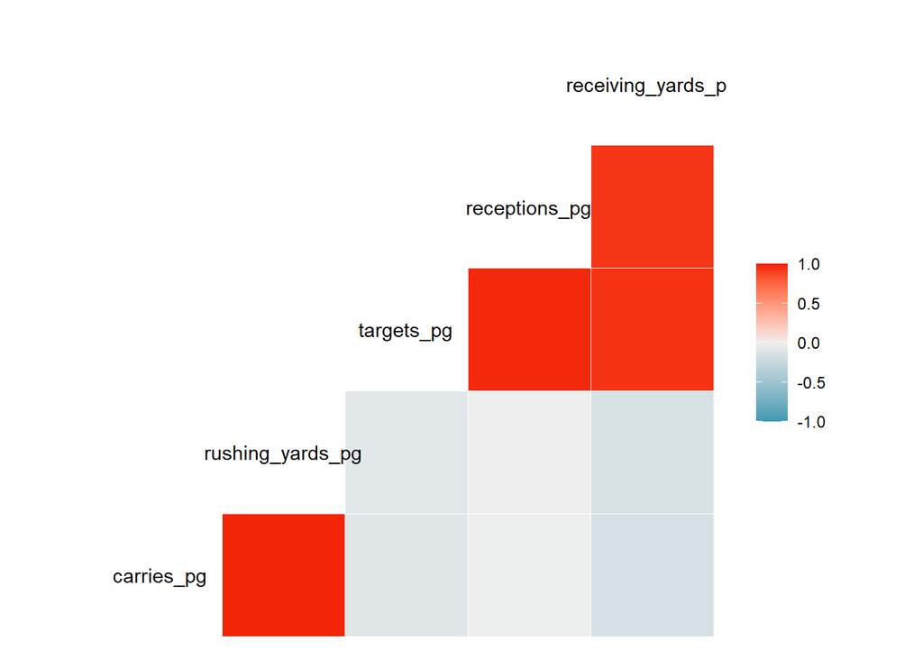

```r
library(GGally)
ggcorr(fantasy2025[,c("carries_pg","rushing_yards_pg",
          "targets_pg","receptions_pg","receiving_yards_pg")])
```

We can fix this by using yards per carry or target instead of per game.

```r
formula2=fantasy_points_ppr~ position+
  carries_pg +
  targets_pg +
  yards_per_carry +
  yards_per_target +
  rushing_tds_pg +
  receiving_tds_pg +
  def_fantasy_points_pg+
  age
fit2=lm(formula2,data=fantasy2025)
library(car)
vif(fit2)
```

```
                          GVIF Df GVIF^(1/(2*Df))
position              3.061369  2        1.322754
carries_pg            5.080691  1        2.254039
targets_pg            1.998570  1        1.413708
yards_per_carry       1.221815  1        1.105357
yards_per_target      1.197334  1        1.094228
rushing_tds_pg        3.392050  1        1.841752
receiving_tds_pg      1.874956  1        1.369290
def_fantasy_points_pg 1.001722  1        1.000861
age                   1.027611  1        1.013711
```

The $R^2$ value for our model isn’t bad

```r
summary(fit2)
```

```
Call:
lm(formula = formula2, data = fantasy2025)

Residuals:
    Min      1Q  Median      3Q     Max
-16.539  -3.385  -0.959   2.031  38.575

Coefficients:
                      Estimate Std. Error t value Pr(>|t|)
(Intercept)            3.97921    0.79875   4.982 6.49e-07 ***
positionTE             0.39185    0.31843   1.231  0.21853
positionWR             0.10718    0.30017   0.357  0.72105
carries_pg             0.51170    0.03776  13.550  < 2e-16 ***
targets_pg             1.45137    0.04345  33.405  < 2e-16 ***
yards_per_carry        0.01237    0.02570   0.481  0.63029
yards_per_target       0.05297    0.02427   2.182  0.02913 *
rushing_tds_pg         2.18949    0.73472   2.980  0.00290 **
receiving_tds_pg       1.58412    0.52390   3.024  0.00251 **
def_fantasy_points_pg -0.12941    0.04662  -2.776  0.00552 **
age                   -0.12290    0.02728  -4.505 6.76e-06 ***
---
Signif. codes:  0 '***' 0.001 '**' 0.01 '*' 0.05 '.' 0.1 ' ' 1

Residual standard error: 5.8 on 5477 degrees of freedom
  (141 observations deleted due to missingness)
Multiple R-squared:  0.3889,    Adjusted R-squared:  0.3878
F-statistic: 348.5 on 10 and 5477 DF,  p-value: < 2.2e-16
```

This is some evidence of heteroscedasticity and a few outliers:

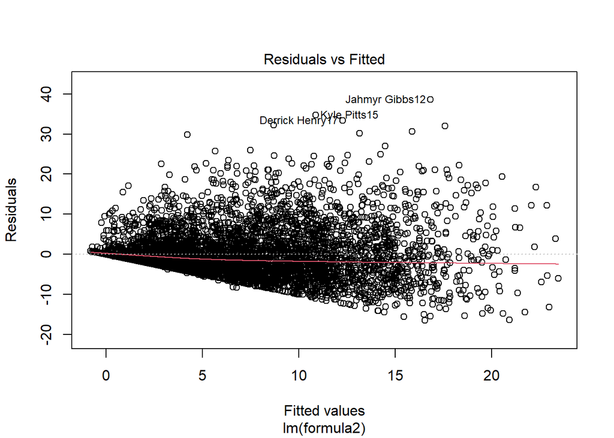

```r
plot(fit2,which=1)
```

Jahmyr Gibbs had a monster week 12 against the giants; nothing to be done about predicting that:

```r
fantasy2025 |>
  dplyr::filter(player_display_name=="Jahmyr Gibbs"&week==12) |>
  select(player_display_name,week,opponent_team,fantasy_points_ppr)
```

```
               player_display_name week opponent_team fantasy_points_ppr
Jahmyr Gibbs12        Jahmyr Gibbs   12           NYG               55.4
```

```r
p=9
2*(p+1)/nrow(fantasy2025)
```

```
[1] 0.003553029
```

```r
head(sort(hatvalues(fit2),decreasing = TRUE))
```

```
 Tyrell Shavers2 Jordan Addison18   Darren Waller5      Josh Downs2
      0.06770791       0.04999297       0.02861061       0.02562490
   Emeka Egbuka2     Woody Marks3
      0.02523032       0.02035191
```

Of course, we should check out of sample accuracy. It looks like the test set accuracy is as good as the train one so yay:

```r
set.seed(315)
n=nrow(fantasy2025)
s=sample(n,0.8*n)
train=fantasy2025[s,]
test=fantasy2025[-s,]
fit_train=lm(formula2,data=train)
yhat=predict(fit_train,test)
SSE=sum((test$fantasy_points_ppr-yhat)^2,na.rm=TRUE)
SST=sum((test$fantasy_points_ppr-mean(test$fantasy_points_ppr))^2,na.rm=TRUE)
cat("Test R^2 is",1-SSE/SST)
```

```
Test R^2 is 0.4012216
```

Also coming back to the point of heteroscedasticity, I learned a new trick for checking if it impacts predictive accuracy - plot the absolute residuals vs predicted values for the test data:

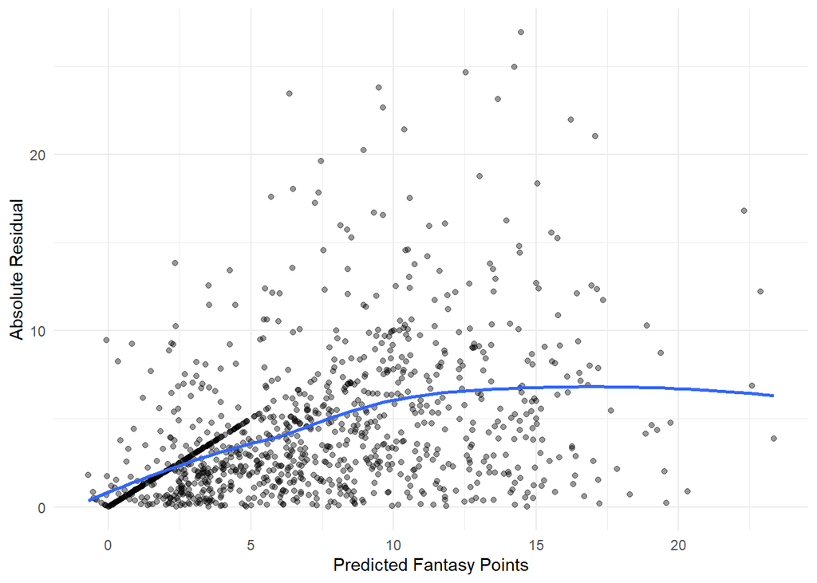

```r
test |>
  mutate(pred=predict(fit2,test),
         resid=fantasy_points_ppr-pred) |>
  ggplot(aes(x = pred, y = abs(resid))) +
  geom_point(alpha = 0.4) +
  geom_smooth(method = "loess", se = FALSE) +
  labs(
    x = "Predicted Fantasy Points",
    y = "Absolute Residual"
  ) +
  theme_minimal()
```

Notice that the error does increase for small $\hat y$ but starts to level off. This means the error doesn’t keep increasing and I wouldn’t be too worried about trying to do anything further to smooth out the variance.

## Footnotes

[^1]: The output here is kind of confusing compared to what we preivously saw because there are some categorical predictors like position with more than two values. Don’t worry about it too much; just use the last column and interpret it like you woudl VIF.